# p8105_hw3_sg4489

sg4489

2024-10-10

```r
library(tidyverse)
```

```r
library(gt)
library(ggplot2)
```

# Problem 1

### Load and describe the raw dataset:

First, I load the dataset: ny_noaa, ensure it is fully evaluated and loaded, and check the head of data to see the basic structure of the data.

```r
# Load the p8105.datasets package
library(p8105.datasets)

# Load the datasets: nyc_airbnb and rest_inspec
data("ny_noaa")

# Use force() to ensure that the dataset is fully evaluated and loaded
#ny_noaa <- force(ny_noaa)
```

Then, convert the data to dataFrame for next processing.

```r
# Convert to dataFrame
ny_noaa_df <- as.data.frame(ny_noaa)

# View the structure of the data frame
glimpse(ny_noaa_df)
```

```
## Rows: 2,595,176
## Columns: 7
## $ id   <chr> "US1NYAB0001", "US1NYAB0001", "US1NYAB0001", "US1NYAB0001", "US1N…
## $ date <date> 2007-11-01, 2007-11-02, 2007-11-03, 2007-11-04, 2007-11-05, 2007…
## $ prcp <int> NA, NA, NA, NA, NA, NA, NA, NA, NA, NA, NA, NA, NA, NA, NA, NA, 3…
## $ snow <int> NA, NA, NA, NA, NA, NA, NA, NA, NA, NA, NA, NA, NA, NA, NA, NA, 3…
## $ snwd <int> NA, NA, NA, NA, NA, NA, NA, NA, NA, NA, NA, NA, NA, NA, NA, NA, 0…
## $ tmax <chr> NA, NA, NA, NA, NA, NA, NA, NA, NA, NA, NA, NA, NA, NA, NA, NA, N…
## $ tmin <chr> NA, NA, NA, NA, NA, NA, NA, NA, NA, NA, NA, NA, NA, NA, NA, NA, N…
```

This dataset contains variables:  
id: Weather station ID  
date: Date of observation  
prcp: Precipitation (tenths of mm)  
snow: Snowfall (mm)  
snwd: Snow depth (mm)  
tmax: Maximum temperature (tenths of degrees C)  
tmin: Minimum temperature (tenths of degrees C)

### Create separate variables for year, month, and day.

```r
# Create new variables: year, month, and day by extracting them from the 'date' column
ny_noaa_clean <- ny_noaa_df %>%
  mutate(
    year = year(date),
    month = month(date),
    day = day(date)
  )

# Check the first few rows to confirm the new columns have been added
head(ny_noaa_clean)
```

```
##            id       date prcp snow snwd tmax tmin year month day
## 1 US1NYAB0001 2007-11-01   NA   NA   NA <NA> <NA> 2007    11   1
## 2 US1NYAB0001 2007-11-02   NA   NA   NA <NA> <NA> 2007    11   2
## 3 US1NYAB0001 2007-11-03   NA   NA   NA <NA> <NA> 2007    11   3
## 4 US1NYAB0001 2007-11-04   NA   NA   NA <NA> <NA> 2007    11   4
## 5 US1NYAB0001 2007-11-05   NA   NA   NA <NA> <NA> 2007    11   5
## 6 US1NYAB0001 2007-11-06   NA   NA   NA <NA> <NA> 2007    11   6
```

### Ensure observations for temperature, precipitation, and snowfall are given in reasonable units.

By running glimpse(ny_noaa_df), I notice that tmax and tmin are chr type variables instead of int type variables, so I need to convert them to numbers.

```r
# Because tmax or tmin are not numeric, convert them to numeric
ny_noaa_clean <- ny_noaa_clean %>%
  mutate(
    tmax = as.numeric(tmax),  # Convert tmax to numeric
    tmin = as.numeric(tmin),  # Convert tmin to numeric
    prcp = as.numeric(prcp)   # Convert prcp to numeric if necessary
  )

# Check the structure of the data again
glimpse(ny_noaa_clean)
```

```
## Rows: 2,595,176
## Columns: 10
## $ id    <chr> "US1NYAB0001", "US1NYAB0001", "US1NYAB0001", "US1NYAB0001", "US1…
## $ date  <date> 2007-11-01, 2007-11-02, 2007-11-03, 2007-11-04, 2007-11-05, 200…
## $ prcp  <dbl> NA, NA, NA, NA, NA, NA, NA, NA, NA, NA, NA, NA, NA, NA, NA, NA, …
## $ snow  <int> NA, NA, NA, NA, NA, NA, NA, NA, NA, NA, NA, NA, NA, NA, NA, NA, …
## $ snwd  <int> NA, NA, NA, NA, NA, NA, NA, NA, NA, NA, NA, NA, NA, NA, NA, NA, …
## $ tmax  <dbl> NA, NA, NA, NA, NA, NA, NA, NA, NA, NA, NA, NA, NA, NA, NA, NA, …
## $ tmin  <dbl> NA, NA, NA, NA, NA, NA, NA, NA, NA, NA, NA, NA, NA, NA, NA, NA, …
## $ year  <dbl> 2007, 2007, 2007, 2007, 2007, 2007, 2007, 2007, 2007, 2007, 2007…
## $ month <dbl> 11, 11, 11, 11, 11, 11, 11, 11, 11, 11, 11, 11, 11, 11, 11, 11, …
## $ day   <int> 1, 2, 3, 4, 5, 6, 7, 8, 9, 10, 11, 12, 13, 14, 15, 16, 17, 18, 1…
```

Now that I’ve confirmed that prcp, tmax, and tmin are all double precision floating point numbers (dbl). Then I can safely convert units of them.

```r
# Convert tmax and tmin from tenths of degrees Celsius to degrees Celsius
# Convert prcp from tenths of millimeters to millimeters
ny_noaa_clean <- ny_noaa_clean %>%
  mutate(
    tmax = tmax / 10,
    tmin = tmin / 10,
    prcp = prcp / 10
  )
```

I convert precipitation from tenths of mm and temperature from tenths of degrees Celsius to mm and degrees Celsius; the original data for snowfall is in mm, so no additional conversion is needed.  
This way, the observed values of temperature(tmax, tmin), precipitation(prcp), and snowfall(snow) are given in reasonable units.

### For snowfall, what are the most commonly observed values? Why?

```r
# Calculate the frequency of each value in the snow column
snow_frequency <- table(ny_noaa_clean %>% pull(snow))

#Find the value that appears most frequently
most_frequent <- names(which.max(snow_frequency))
```

```r
# Count the number of 0 values in the snow column
zero_count <- sum(ny_noaa_clean %>% pull(snow) == 0, na.rm = TRUE)

# Count the number of NA values in the snow column
na_count <- sum(is.na(ny_noaa_clean %>% pull(snow)))

#Compare the counts
cat("Number of 0s:", zero_count, "\n")
```

```
## Number of 0s: 2008508
```

```r
cat("Number of NAs:", na_count, "\n")
```

```
## Number of NAs: 381221
```

```r
# Check which is larger
if (zero_count > na_count) {
  cat("There are more 0s than NAs.\n")
} else if (zero_count < na_count) {
  cat("There are more NAs than 0s.\n")
} else {
  cat("The number of 0s and NAs is equal.\n")
}
```

```
## There are more 0s than NAs.
```

In snowfall data, the most common observed value is often 0, and there are several reasons for this:  
1. Snowfall mainly occurs in winter: In most regions, snowfall is limited to the winter months. Outside of winter, snow is rare or nonexistent, leading to a high number of days with no snowfall recorded (0).  
2. Even in colder climates, snowfall doesn’t happen every day during the winter. Snowfall events are relatively infrequent, so the majority of days, even in winter, have no snowfall, contributing to the large number of 0 values.  
3. Many weather stations consistently record data daily, even when there is no precipitation. On days with no snowfall, a 0 is logged. This frequent recording of 0 on non-snow days leads to its dominance in the dataset.

Finally, rearrange column names to make the data more readable and describe the processed data.

```r
# Rearrange columns
ny_noaa_clean <- ny_noaa_clean %>%
  select(id, date, year, month, day, tmax, tmin, prcp, snow, snwd)

# Displaying organized data
glimpse(ny_noaa_clean)
```

```
## Rows: 2,595,176
## Columns: 10
## $ id    <chr> "US1NYAB0001", "US1NYAB0001", "US1NYAB0001", "US1NYAB0001", "US1…
## $ date  <date> 2007-11-01, 2007-11-02, 2007-11-03, 2007-11-04, 2007-11-05, 200…
## $ year  <dbl> 2007, 2007, 2007, 2007, 2007, 2007, 2007, 2007, 2007, 2007, 2007…
## $ month <dbl> 11, 11, 11, 11, 11, 11, 11, 11, 11, 11, 11, 11, 11, 11, 11, 11, …
## $ day   <int> 1, 2, 3, 4, 5, 6, 7, 8, 9, 10, 11, 12, 13, 14, 15, 16, 17, 18, 1…
## $ tmax  <dbl> NA, NA, NA, NA, NA, NA, NA, NA, NA, NA, NA, NA, NA, NA, NA, NA, …
## $ tmin  <dbl> NA, NA, NA, NA, NA, NA, NA, NA, NA, NA, NA, NA, NA, NA, NA, NA, …
## $ prcp  <dbl> NA, NA, NA, NA, NA, NA, NA, NA, NA, NA, NA, NA, NA, NA, NA, NA, …
## $ snow  <int> NA, NA, NA, NA, NA, NA, NA, NA, NA, NA, NA, NA, NA, NA, NA, NA, …
## $ snwd  <int> NA, NA, NA, NA, NA, NA, NA, NA, NA, NA, NA, NA, NA, NA, NA, NA, …
```

# Describe the cleaned data

```r
# View summary statistics for each column
summary(ny_noaa_clean)
```

```
##       id                 date                 year          month
##  Length:2595176     Min.   :1981-01-01   Min.   :1981   Min.   : 1.000
##  Class :character   1st Qu.:1988-11-29   1st Qu.:1988   1st Qu.: 4.000
##  Mode  :character   Median :1997-01-21   Median :1997   Median : 7.000
##                     Mean   :1997-01-01   Mean   :1996   Mean   : 6.565
##                     3rd Qu.:2005-09-01   3rd Qu.:2005   3rd Qu.:10.000
##                     Max.   :2010-12-31   Max.   :2010   Max.   :12.000
##
##       day             tmax              tmin              prcp
##  Min.   : 1.00   Min.   :-38.9     Min.   :-59.4     Min.   :   0.00
##  1st Qu.: 8.00   1st Qu.:  5.0     1st Qu.: -3.9     1st Qu.:   0.00
##  Median :16.00   Median : 15.0     Median :  3.3     Median :   0.00
##  Mean   :15.73   Mean   : 14.0     Mean   :  3.0     Mean   :   2.98
##  3rd Qu.:23.00   3rd Qu.: 23.3     3rd Qu.: 11.1     3rd Qu.:   2.30
##  Max.   :31.00   Max.   : 60.0     Max.   : 60.0     Max.   :2286.00
##                  NA's   :1134358   NA's   :1134420   NA's   :145838
##       snow             snwd
##  Min.   :  -13    Min.   :   0.0
##  1st Qu.:    0    1st Qu.:   0.0
##  Median :    0    Median :   0.0
##  Mean   :    5    Mean   :  37.3
##  3rd Qu.:    0    3rd Qu.:   0.0
##  Max.   :10160    Max.   :9195.0
##  NA's   :381221   NA's   :591786
```

1. The dataset contains 2,595,176 observations and 7 variables, covering weather measurements from NOAA weather stations from 1981 to 2010. The key variables recorded are daily precipitation, snowfall, snow depth, maximum temperature, and minimum temperature. Below is a summary of the structure and key variables.
2. Key variables and their missing data:  
   *id*: Weather station ID.  
   *date*: Date of observation, ranging from 1981-01-01 to 2010-12-31.  
   *prcp*: Precipitation (mm). There are significant missing values (NAs: 145,838), and the maximum recorded value is 2,286 millimeters.  
   *snow*: Snowfall (mm). The most common value is 0, and the maximum recorded snowfall is 10,160 mm.  
   *snwd*: Snow depth (mm). The snow depth ranges from 0 to 9,195 mm, with significant missing values (NAs: 591,786).  
   *tmax*: Maximum temperature (degrees C) with many missing values (NAs: 1,134,358). The maximum value is 60.0, and the minimum is -38.9.  
   *tmin*: Minimum temperature (degrees C) with similar missing values as tmax (NAs: 1,134,420). The range is from -59.4 to 60.0 degrees.
3. Summary: The dataset provides a rich collection of daily weather observations over a long time period but suffers from a high degree of missing data, especially in the temperature and snow-related variables. This will require careful handling and potentially imputing or filtering for missing values in any further analysis.

### Two-Panel Plot for Max Temperature in January and July

Now, I can create a two-panel plot showing the average max temperature in January and July for each station across years. This will allow us to observe any patterns or outliers.

```r
# Filter for January and July, calculate average max temperature per station and year
jan_jul_temps <- ny_noaa_clean %>%
  filter(month %in% c(1, 7)) %>%  # Filter for January and July
  group_by(id, year, month) %>%
  summarise(mean_tmax = mean(tmax, na.rm = TRUE)) %>%  # Calculate average max temp
  ungroup()
```

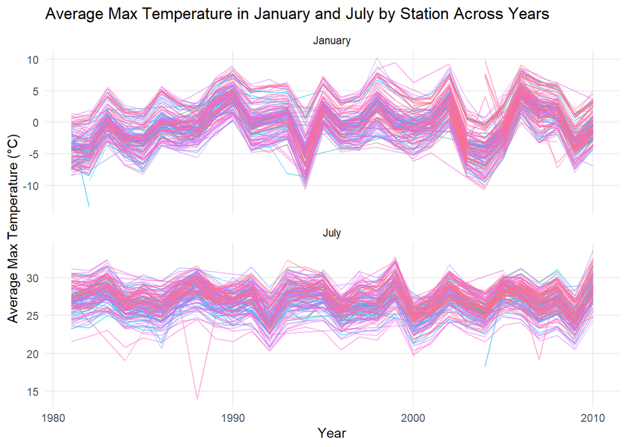

```r
# Create the two-panel plot using ggplot, fixing the degree symbol issue
ggplot(jan_jul_temps, aes(x = year, y = mean_tmax, color = id)) +
  geom_line(alpha = 0.5) +  # Line plot for each station
  facet_wrap(~ month, scales = "free_y", ncol = 1, labeller = as_labeller(c(`1` = "January", `7` = "July"))) +  # Separate panels
  labs(
    title = "Average Max Temperature in January and July by Station Across Years",
    x = "Year",
    y = "Average Max Temperature (\u00B0C)",  # Proper degree symbol
    color = "Station ID"
  ) +
  theme_minimal() +
  theme(legend.position = "none",  # Remove legend (too many lines)
        panel.grid.minor = element_blank())
```

Outliers:  
Unusual Spikes/Dips: Sudden deviations, like extreme highs in January or sharp drops in July, could indicate data errors or unusual weather events (e.g., cold snaps, heatwaves).  
Missing Data: Gaps or incomplete records can also create apparent outliers, disrupting the overall trend.

### Make a two-panel plot showing (i) tmax vs tmin for the full dataset.

A scatterplot for tmax vs tmin might not be ideal due to the large amount of data. Instead, we can use a hexbin plot to handle the dense data points. For the snowfall distribution, we will use boxplots to show the distribution of snowfall values by year.

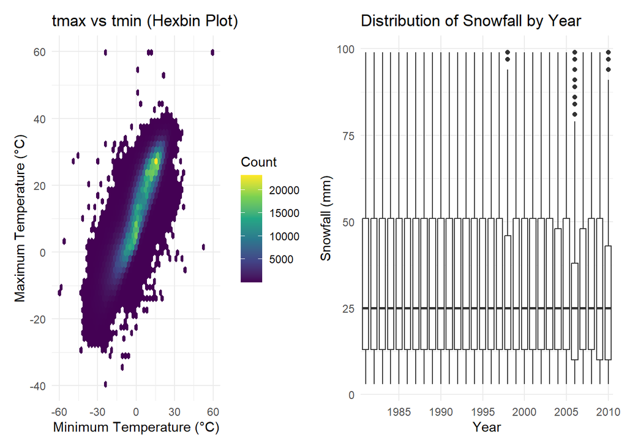

```r
# 1. Plot tmax vs tmin using hexbin plot
tmax_tmin_plot <- ny_noaa_clean %>%
  filter(!is.na(tmax) & !is.na(tmin)) %>%  # Filter out missing values
  ggplot(aes(x = tmin, y = tmax)) +
  geom_hex(bins = 50) +  # Hexbin plot to handle dense data
  scale_fill_viridis_c() +
  labs(
    title = "tmax vs tmin (Hexbin Plot)",
    x = "Minimum Temperature (\u00B0C)",  # Unicode for degree symbol
    y = "Maximum Temperature (\u00B0C)",  # Unicode for degree symbol
    fill = "Count"
  ) +
  theme_minimal()

# 2. Distribution of snowfall values greater than 0 and less than 100, by year
snowfall_plot <- ny_noaa_clean %>%
  filter(snow > 0 & snow < 100) %>%   # Filter snowfall values between 0 and 100
  group_by(year) %>%
  ggplot(aes(x = factor(year), y = snow)) +
  geom_boxplot() +
  labs(
    title = "Distribution of Snowfall by Year",
    x = "Year",
    y = "Snowfall (mm)"
  ) +
  scale_x_discrete(breaks = seq(1980, 2020, by = 5)) +  # Show every 5 years on the x-axis
  theme_minimal()

# Combine both plots using patchwork
library(patchwork)
tmax_tmin_plot + snowfall_plot +
  plot_layout(widths = c(1, 1.5))  # Make the right plot 1.5 times wider
```

The first panel will show a hexbin plot of tmax vs tmin.  
In the first panel (tmax vs tmin), we observe a strong linear relationship between maximum and minimum temperatures, as expected. Most temperatures cluster between 0°C and 30°C, with extreme outliers below -30°C and above 50°C, though these are rare.